# Model Combination

73-423 Forecasting for Economics and Business

## Model Combination

- Handling multiple forecasts or models
  - Model Selection
  - Model Averaging
  - Model Combination
- Bayesian and dynamic approaches
- Applications

## Combining Forecasts

- By now, we have seen a wide variety of forecasting methods and models
- Differences in procedure partly come from differences in goals
  - Express in terms of loss functions and approach (worst-case or average risk, regret)
- Other differences come from class of models or predictors used
  - ARIMA, State Space, ETS, Additive, nonlinear, judgmental, etc
- Often, different methids will lead to fairly different results
- Given many forecasts, what can we do with them? (At least) 3 Choices
  - Model **Selection**: Pick one “best” forecast
  - Model **Averaging**: Take some (weighted) combination
  - Model **Combination**: Put together in some way which need not be an average
- In forecasting competitions (Kaggle, Netflix Prize, etc) extremely common that winning entry is some combination of other entries
  - **Ensembles** of models can outperform even the best *individual model*

## A Unified Framework

- Let $\mathcal{F}=\{f_m(\mathcal{Y}_{T}):\ m=1\ldots M\}$ be a set of forecasts or forecast rules
  - These may be simple fixed rules, or the result of some complicated forecasting procedure
- Let $\mathcal{S}\subset\mathbb{R}^{m}$ be a set of possible ways to combine the forecasts.
- A forecast combination is then a rule $f^{s}(\mathcal{Y}_T)=\sum_{m=1}^{M}s_{m}f_m(\mathcal{Y}_T)$ for some $s\in\mathcal{S}$
- A forecast combination procedure is a method for choosing a rule $s\in\mathcal{S}$
  - $\mathcal{S}_0=\{s\in\{0,1\}^m:\ \sum_{m=1}^{M}s_m=1\}$ is **model selection**
  - $\mathcal{S}_1=\{s\in[0,1]^m:\ \sum_{m=1}^{M}s_m=1\}$ is **model averaging**
  - $\mathcal{S}_2=\{s\in\mathbb{R}^m\}$ is **model combination**
- A variety of methods and perspectives can be used to define a procedure for choosing $s\in\mathcal{S}$

## Model Selection

- In cases where $\mathcal{F}$ consists of fixed functions, model selection procedures with good statistical properties already known
  - Empirical Risk Minimization solves $m^*=\underset{m\in 1\ldots M}{\arg\min}\sum_{t=1}^{T-h}\ell(y_{t+h},f_m(\mathcal{Y}_t))$
- A more interesting case occurs where each model $m=1\ldots M$ is itself a procedure based on a selection rule
- E.g., $\{\mathcal{F}_m\}_{m=1}^{M}$ is a set of sets of rules
  - Rules can be *nested*, in which case $\mathcal{F}_m\subseteq\mathcal{F}_{m+1}$, or non-nested
  - Non-nested sets which are *disjoint* satisfy $\mathcal{F}_m\cap\mathcal{F}_n=0$ for $n\neq m$
- ERM over the ERM estimates from each set is equivalent to ERM over the union of sets $\cup_{m=1}^{M}\mathcal{F}_m$
  - Performance depends on complexity of class of all possible models that could be chosen
  - In the disjoint case, this selects a single $m^*$ as the “best” model
  - In cases where rule sets overlap, may not single out a particular $\mathcal{F}_m$ uniquely
    - Fine if you don’t need it
- If you want to distinguish, or worry about performance loss from complex joint model class, can perform *penalized empirical risk minimization*
- Use an **information criterion** (AIC(c), BIC, etc) which depends on model $m$ chosen to decide between models

## Model Averaging - Equal Weights

- Case where $\mathcal{S}=\mathcal{S}_1$, the probability simplex, brings us away from previous methods
- Simplest model averaging procedure, and one with surprisingly good performance, is **equal weights**
  - $s=(\frac{1}{m},\frac{1}{m},\ldots,\frac{1}{m})$, no matter what data is used
- If we have several forecasting methods and don’t have a particularly good reason to think one should be much better or worse than others, average may do well
- Combination may even do better than best individual forecast, from risk persepective
  - Combination has lower variance than any individual forecast, making results more precise, especially if forecasts not perfectly correlated
    - $Var(\frac{1}{M}\sum_{m=1}^{M}\widehat{y}_{t+h,m})=\frac{1}{M^2}\left(\sum_{m=1}^{M}Var(\widehat{y}_{t+h,m})+\sum_{m=1}^{M}\sum_{n\neq m}Cov(\widehat{y}_{t+h,m},\widehat{y}_{t+h,n})\right)$
  - If forecasts each have low bias $\mathbf{E}[y_{t+h}-\widehat{y}_{t+h,m}]\approx 0$, this increase in precision improves square loss risk
- What is special about equal weights? (cf Diebold 2017)
  - Allows each method to contribute, without putting excessive confidence in any particular method
    - If all methods are making similar forecasts, result is not so different than any one, if some are fairly different, result is incorporated, but only partially
  - Simplicity: because not dependent on data, reduces chance of overfitting and variance of forecast
  - Minmax perspective: it minimizes max risk over possible error distributions among all weighted averages of unbiased forecasts
- Equal weights is a good way to combine a set of diverse, individually good but possibly imprecise forecasts

## Model Averaging - Risk Minimization

- In cases where models may be of differing quality, with some possibly way better or worse than others, may do better by using data to choose a combination
- Choose $s\in\mathcal{S}$ to minimize measure of loss $\underset{s\in\mathcal{S}}{\arg\min}\sum_{t=1}^{T-h}\ell(y_{t+h},\sum_{m=1}^{M}s_mf_m(\mathcal{Y}_{t}))$
- Weights act like new parameter, to be chosen alongside other parameters of the model
- Reproduces ERM when $\mathcal{S}=\mathcal{S}_0$, but in $\mathcal{S}_1$ case produces new model: may fit better than any one model in set
  - If each $f_m$ is ERM over $\mathcal{F}_m=\{f(,\theta):\ \theta\in\Theta_m\}$, combination is ERM over $\{\sum_{m=1}^{M}s_mf_{\theta}(\mathcal{Y}_T):\ s\in\mathcal{S},\theta\in\Theta_m\}$
  - Produces low risk relative to best model in **combined class** under usual ERM conditions (stationarity, weak dependence, low complexity)
- Especially if models are very different, new model class may be able to produce very different results than any individual rule, at cost of small increase in complexity
  - Useful especially if model classes non-nested, nonlinear, less so otherwise
  - E.g., if classes are different orders of autoregression model, combination still an autoregression model and so no help
  - But if one is, e.g., an ETS model and one is an autoregression, combination need not be in either class
- Choosing weights allows variance reduction benefits like equal weights does, but can use performance to ensure bias is also controlled, in case set contains some bad models
  - Cost is a bit of additional variance since weight choice adds complexity

## Alternate Selection Approaches

- Equivalence to some form of ERM holds when $s\in\mathcal{S}$ chosen by risk minimization over set $\mathcal{F}$ consisting of fixed set of functions or $M$ separate ERM estimates
- If models are nested, using empirical risk in choosing $s$ does not usually allow distinguishing between models
  - If largest class is also **convex**, model averaging just picks model from within largest possible class
- If $s\in\mathcal{S}$ chosen by alternate criterion, can produce a non-equivalent procedure
  - Allows weight to be given to predictor $\widehat{f}_m$ for any $m$, capturing benefits for risk of reduced complexity
- Risk approximable by **Cross Validation**: $\widehat{R}^{TSCV}(s)=\sum_{t=1}^{T-h}\ell(y_{t+h},\sum_{m=1}^{M}s_mf_m(\mathcal{Y}_{t}))$
  - May provide better estimate of risk of different combinations, accounting for properties of $f_m$ as a function of the data
  - Can also use other forms of cross validation (like K-fold), or a split into a training and validation set, to measure risk
- Different data used to optimize over $\mathcal{S}$ than to construct $f_m$
  - Reduces complexity and so amount of overfitting relative to case of joint combination
- Also allows capturing qualities of $f_m$ *not* defined as an empirical risk minimizer
  - E.g. methods coming from expert judgment, penalized approaches, or machine learning methods
  - Like smaller models in nested setting, these often have good risk performance due to way model chosen in a way not captured by empirical risk

## Model Combination

- In principle, the best possible combination of models could lie *outside* the set of weighted averages
- Sometimes, a model should have **negative** weight: better to predict opposite of what it recommends
- A model could also be given a weight **more than one**: go *even farther* in the direction it recommends
- Case for weights outside $[0,1]$ stronger when using multiple models in combination
  - *Given the other models*, there may be additional information in another model, but remaining variation might need to be rescaled or reversed
- All of these can be accommodated by setting $\mathcal{S}=\mathbb{R}^M$
- Sometimes called **regression** combination, because $\sum_{m=1}^{M}s_mf_m(\mathcal{Y}_t)$ is the same form as a regression function $\sum_{j=1}^{J}b_jz_j$ with coefficients $s_m$ and predictors $f_m$
  - If predictors are fixed sequences, choosing weights is exactly regression: can add a constant by including the constant forecast
- If forecasts $f_m$ are generated by some procedure, can use empirical or some cross-validation risk to pick a good combo
  - Properties similar to averaging case, now with a different function class
- Can be useful to penalize choice of weights by adding penalty $\lambda\mathcal{P}(s)$ to (empirical or CV) risk estimate
  - E.g. $\mathcal{P}(s)=\sum_{m=1}^M|s_m|$ gives Lasso estimate, which downweights low quality forecasts to 0
  - Penalization reduces variance of weight choices and overfitting, which can be quite bad in regression case where weights completely unbounded

## Application: Model Combination for Oil Price Forecasting

- Consider forecasting monthly growth in price of West Texas Intermediate Crude Oil, in $/barrel
  - Measure of Oil Prices at point for import to US, before refining
- Apply 3 possible models: ARMA(1,1), ARCH(2), and AR(1)-ARCH(2)
  - ARCH model has formula $y_t=\mu+\sigma_te_t$, $\sigma_t=\sqrt{\omega+b_1(y_{t-1}-\mu)^2+b_2(y_{t-2}-\mu)^2}$ with non-negative coefficients
    - Simple way to model changing variance over time
  - AR-ARCH model is ARCH model applied to residuals of AR model
  - ARCH and AR-ARCH models are nested, but ARMA model isn’t: captures different features of data
- Compare model selection, averaging, and combination, all using mean squared error criterion
  - Compare both case where parameters of each estimated on whole series, and where risk of combinations estimated by cross validation

## Model predictions and combinations

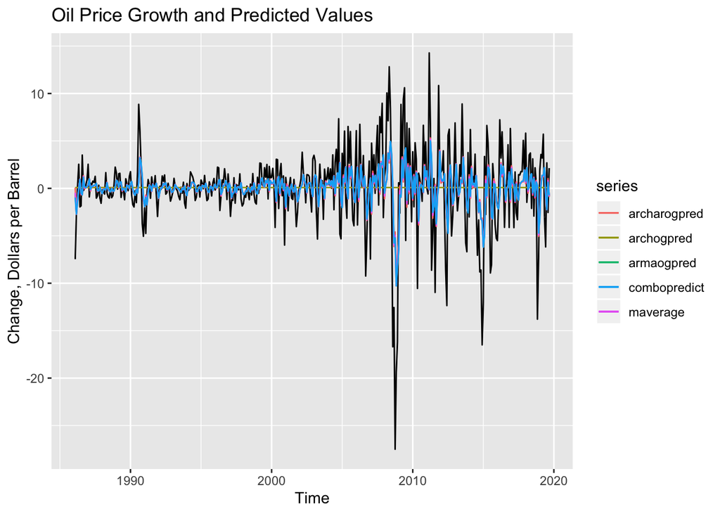

```r
library(knitr)
library(kableExtra)
library(fredr) #FRED data
library(fpp2) #Forecasting
library(tseries) #Time series commands, including ARCH models
library(rugarch) #Many versions of ARCH models and other variance fitting models
library(rstan) #Bayesian estimation
library(loo) #Bayesian Model selection
library(bridgesampling) #Bayesian model comparison and averaging
library(mgcv) #Contains methods for fitting constrained regression, including best weighted average problems
library(gridExtra) #Graph Display

fredr_set_key("8782f247febb41f291821950cf9118b6") #Key I obtained for this class

WTI<-fredr(series_id = "MCOILWTICO",units="chg") #Monthly Growth in West Texas Intermediate Crude Oil Price
      #Measure of Oil Prices at point for import to US, before refining

#Format the series as monthly time series object, starting at the first date
oilgrowth<-window(ts(WTI$value,frequency=12,start=c(1986,1),names="OilPrice"),start=c(1986,2))

# Fit a set of models to the series

# ARMA(1,1)
armaog<-arima(oilgrowth,order=c(1,0,1))

# ARMA(1,1) Forecast

armaogfc<-forecast(armaog,h=5)

#ARCH(2)
#y_t=e_t(b_1+b_2y_{t-1}^2+b_3y_{t-2}^2)

#Use "garch" command in tseries library to fit by maximum likelihood
#archog<-garch(oilgrowth,order=c(0,2))

#Use rugarch library to fit ARCH(2) model with mean given by AR(1)

spec <- ugarchspec(variance.model = list(model = "sGARCH",
                                         garchOrder = c(0,2),
                                         submodel = NULL,
                                         external.regressors = NULL,
                                         variance.targeting = FALSE),

                   mean.model     = list(armaOrder = c(1, 0),
                                         external.regressors = NULL,
                                         distribution.model = "norm",
                                         start.pars = list(),
                                         fixed.pars = list()))

# Fit model by MLE
archarog <- ugarchfit(spec = spec, data = oilgrowth, solver.control = list(trace=0))

# Produce forecasts
archarogfc <- ugarchforecast(archarog, n.ahead=5)

#Use rugarch library to fit ARCH(2) model with mean given by constant

spec1 <- ugarchspec(variance.model = list(model = "sGARCH",
                                         garchOrder = c(0,2),
                                         submodel = NULL,
                                         external.regressors = NULL,
                                         variance.targeting = FALSE),

                   mean.model     = list(armaOrder = c(0, 0),
                                         external.regressors = NULL,
                                         distribution.model = "norm",
                                         start.pars = list(),
                                         fixed.pars = list()))

# Fit model by MLE
archog <- ugarchfit(spec = spec1, data = oilgrowth, solver.control = list(trace=0))

# Produce forecasts
archogfc <- ugarchforecast(archog, n.ahead=5)

# Produce series of predictions

#Predicted values from ARMA model
armaogpred<-oilgrowth-armaog$residuals
archogpred<-oilgrowth-archog@fit$residuals
archarogpred<-oilgrowth-archarog@fit$residuals

# Compare RMSE
armaogerr<-accuracy(armaogpred,oilgrowth)
archogerr<-accuracy(archogpred,oilgrowth)
archarogerr<-accuracy(archarogpred,oilgrowth)

s0<-c(1,0,0) #ARMA model minimizes MSE

# Model combination

#Unrestricted combination is linear regression
mcombo<-lm(oilgrowth~0+armaogpred+archogpred+archarogpred)

combopredict<-ts(predict(mcombo),frequency=12,start=c(1986,2))

s2<-mcombo$coefficients

#Restricted combo to weighted average fit by constrained least squares
#See ?pcls help for syntax: below code ensures coefficients sum to 1 and are non-negative
M<-list(X=matrix(0,length(oilgrowth),3),p=c(0.33,0.33,0.34),off=array(0,0),S=list(),
Ain=matrix(0,3,3),bin=c(0,0,0),C=matrix(1,1,3),sp=array(0,0),y=oilgrowth,w=oilgrowth*0+1)
M$X[,1]<-armaogpred
M$X[,2]<-archogpred
M$X[,3]<-archarogpred
M$Ain[1,1]<-1
M$Ain[2,2]<-1
M$Ain[3,3]<-1
#Find constrained least squares solution
pcls(M)->M$p

s1<-M$p #MSE optimizing weighted average of 3 models
#Optimal average
maverage<-s1[1]*armaogpred+s1[2]*archogpred+s1[3]*archarogpred

#Plot series and predictions
autoplot(oilgrowth)+autolayer(armaogpred)+autolayer(archogpred)+
  autolayer(archarogpred)+autolayer(maverage)+autolayer(combopredict)+ggtitle("Oil Price Growth and Predicted Values")+
  ylab("Change, Dollars per Barrel")
```

## Cross Validated Predictions and Optimal Combinations

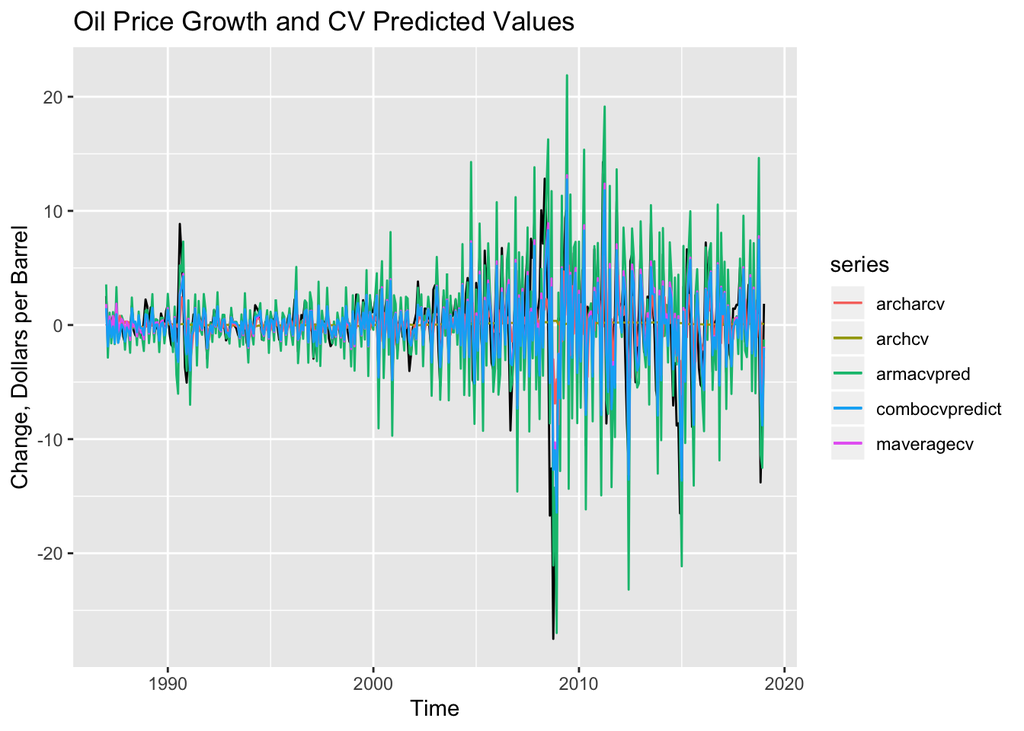

```r
## Produce time series CV forecast errors from each method

farma <- function(x, h){forecast(Arima(x, order=c(1,0,1)), h=h)}
e1 <- tsCV(oilgrowth, farma, h=1)

#Produce predictions from rolling forecasts
armacvpred<-window(oilgrowth,start=c(1987,1),end=c(2019,1))-window(e1,start=c(1987,1),end=c(2019,1))

# rugarch library has its own function for tsCV forecasts, called ugrachroll
# For computational speed, choose new parameters only every 5 data points

#For basic ARCH(2) model
mod1 = ugarchroll(spec1, data = oilgrowth, n.ahead = 1,
n.start = 10,  refit.every = 5, refit.window = "recursive",
solver = "hybrid", fit.control = list(), calculate.VaR = FALSE,
keep.coef = TRUE)

#Mean predictions
archcvpred<-ts(mod1@forecast$density$Mu,frequency=12,start=c(1986,12))

#For AR(1)-ARCH(2) model
mod = ugarchroll(spec, data = oilgrowth, n.ahead = 1,
n.start = 10,  refit.every = 5, refit.window = "recursive",
solver = "hybrid", fit.control = list(), calculate.VaR = FALSE,
keep.coef = TRUE)

#Mean predictions
archarcvpred<-ts(mod@forecast$density$Mu,frequency=12,start=c(1986,12))

#Truncate series to window of predictions
ogwindow<-window(oilgrowth,start=c(1987,1),end=c(2019,1))
archcv<-window(archcvpred,start=c(1987,1),end=c(2019,1))
archarcv<-window(archarcvpred,start=c(1987,1),end=c(2019,1))

# Compare RMSE
armacverr<-accuracy(armacvpred,ogwindow)
archcverr<-accuracy(archcv,ogwindow)
archarcverr<-accuracy(archarcv,ogwindow)

s0cv<-c(1,0,0) #ARMA model still minimizes MSE

#Unrestricted combination is linear regression
mcombocv<-lm(ogwindow~0+armacvpred+archcv+archarcv)

combocvpredict<-ts(predict(mcombocv),frequency=12,start=c(1987,1))

s2cv<-mcombocv$coefficients

#Restricted combo to weighted average fit by constrained least squares
#See ?pcls help for syntax: below code ensures coefficients sum to 1 and are non-negative
M2<-list(X=matrix(0,length(ogwindow),3),p=c(0.33,0.33,0.34),off=array(0,0),S=list(),
Ain=matrix(0,3,3),bin=c(0,0,0),C=matrix(1,1,3),sp=array(0,0),y=ogwindow,w=ogwindow*0+1)
M2$X[,1]<-armacvpred
M2$X[,2]<-archcv
M2$X[,3]<-archarcv
M2$Ain[1,1]<-1
M2$Ain[2,2]<-1
M2$Ain[3,3]<-1
#Find constrained least squares solution
pcls(M2)->M2$p

s1cv<-M2$p #MSE optimizing weighted average of 3 models

#Optimal average
maveragecv<-s1cv[1]*armacvpred+s1cv[2]*archcv+s1cv[3]*archarcv

#Plot Forecasts and combinations

autoplot(ogwindow)+autolayer(armacvpred)+autolayer(archcv)+autolayer(archarcv)+
  autolayer(maveragecv)+autolayer(combocvpredict)+ggtitle("Oil Price Growth and CV Predicted Values")+
  ylab("Change, Dollars per Barrel")
```

## Combination Results

- Optimal combinations may take negative and strongly positive weights, because additional information in extra models may predict in wrong direction
- ARCH model, nested in AR-ARCH, has low weight in non-CV case, but more important when CV used
- ARMA model makes best predictions, but combining with AR-ARCH helpful in cross-validated case

```r
Weight<-c("ARMA(1,1)","ARCH(2)","AR(1)ARCH(2)")
seltable<-data.frame(Weight,s0,s1,s2,s0cv,s1cv,s2cv)
colnames(seltable)<-c("Model","Selection","Average","Combination",
                       "Selection (CV)","Average (CV)","Combination (CV)")

kable(seltable,
  caption="Optimal Model Weights by Method") %>%
  kable_styling(bootstrap_options = "striped")
```

Optimal Model Weights by Method

|  | Model | Selection | Average | Combination | Selection (CV) | Average (CV) | Combination (CV) |
| --- | --- | --- | --- | --- | --- | --- | --- |
| armaogpred | ARMA(1,1) | 1 | 0.998383724 | 1.9312723 | 1 | 0.50420777 | 0.5019803 |
| archogpred | ARCH(2) | 0 | 0.001616276 | 0.0818078 | 0 | 0.04215205 | -2.2076654 |
| archarogpred | AR(1)ARCH(2) | 0 | 0.000000000 | -0.9439869 | 0 | 0.45364018 | 0.4383453 |

## Bayesian Approach

- In the Bayesian setting, different forecasts come from different *probability models*
- Let $\mathcal{M}=\left\{\{p_m(.,\theta):\ \theta\in\Theta_m\}_{m=1}^{M},\{\pi_m(\theta)\}_{m=1}^{M}\right\}$ be a set of models $m=1\ldots M$ consisting of a likelihood $p_m$ and a prior $\pi_m$
  - For example, ARIMA(p,d,q) models of different order, or state space models with different components, or different priors for the same model
- How should we take the information contained in these different models and produce a good forecast?
- Recall the Bayesian procedure for building a forecast using a *single* model
- For each $m$, construct a posterior $\pi(\theta|\mathcal{Y}_T,m)$ and a posterior predictive distribution $p(y_{T+1}|\mathcal{Y}_{T},m)$ by Bayes rule
- Given a loss function $\ell(,)$ can build point forecasts $\widehat{y}_{T+1,m}=f_m(\mathcal{Y}_T)$ by finding $\widehat{y}_{T+1,m}=\underset{\widehat{y}_{T+1}}{\arg\min}\int\ell(y_{T+1},\widehat{y}_{T+1})p(y_{T+1}|\mathcal{Y}_{T},m)dy_{T+1}$
- $\{\widehat{y}_{T+1,m}\}_{m=1}^{M}$ are a set of forecast rules which can be combined by any model combination procedure as before
  - Can even be combined with non-Bayesian forecast approaches, as once model is reduced to single output, no need to know where it came from
- Alternately, can use combination methods which use the additional information provided by Bayesian models

## Bayesian Model Averaging

- Given a set $\mathcal{M}$ of probability models, the fully Bayesian approach is to put a prior over it
- Let $\nu(m)$ be a prior weight attached to model $m\in\mathcal{M}$, reflecting information about the plausibility of different models
- For each $m$, $p(\tilde{\mathcal{Y}}_T|m)=\int_{\theta\in\mathcal{\Theta_m}} p_m(\tilde{\mathcal{Y}}_T,\theta)\pi_m(\theta)d\theta$ is the prior probability of observing data set $\tilde{\mathcal{Y}}_T$
  - Evaluated at $\tilde{\mathcal{Y}}_T=\mathcal{Y}_T$, it gives us the **marginal likelihood** of the data given the model $m$
- Applying Bayes rule, one can construct a posterior distibution over the set of models
  - $\nu(m|\mathcal{Y}_T)=\frac{p(\mathcal{Y}_T|m)\nu(m)}{\sum_{j=1}^{M}p(\mathcal{Y}_t|j)\nu(j)}$ is posterior weight of model $m$
- Given a posterior distribution, posterior predictive distribution is $\sum_{m=1}^{M}p(y_{T+1}|\mathcal{Y}_T,m)\nu(m|\mathcal{Y}_T)$
  - This is a weighted average of posterior predictive distributions of each model
- Optimal forecast is $\underset{\widehat{y}_{T+1}}{\arg\min}\int\ell(y_{T+1},\widehat{y}_{T+1})\sum_{m=1}^{M}p(y_{T+1}|\mathcal{Y}_T,m)\nu(m|\mathcal{Y}_T)dy_{T+1}$
- *Exactly* the same prediction as when $m$ is a parameter and Bayes applied with priors $\pi(\theta,m)=\pi_m(\theta)\nu(m)$
  - Bayesian model averaging is just Bayes!
  - Not generally the same as $\sum_{m=1}^{M}\widehat{y}_{T+1,m}\nu(m|\mathcal{Y}_{T+1})$: we average the posteriors, not the forecasts themselves

## Bayes Factors

- For model *selection*, might want to select the model with the highest posterior probability
- For comparing two models, one can look at the ratio $\frac{p(j|\mathcal{Y}_T)}{p(k|\mathcal{Y}_T)}=\frac{p(\mathcal{Y}_T|j)\nu(j)}{p(\mathcal{Y}_T|k)\nu(k)}$
- Taking logs, this is given by $\log p(\mathcal{Y}_T|j)-\log p(\mathcal{Y}_T|k) +\log\nu(j)-\log\nu(k)$
  - With equal priors, $\log\nu(j)-\log\nu(k)=0$, and difference is just difference in log marginal likelihood
  - This difference $\log p(\mathcal{Y}_T|j)-\log p(\mathcal{Y}_T|k)$ is called the **Bayes Factor**
- Can use marginal likelihoods, just like information criteria, to choose between Bayesian models
- A large value suggests observed data would be much more likely to be seen under model $j$ than model $k$
  - If prior information in favor of one model exists, can adjust Bayes factor by prior differences

## Limitations of Bayes Factors

- Bayes factor uses particular interpretation of “good model”, using *log probability* as loss function
  - Very sensitive to avoiding assigning low probability to events actually seen
- Empirically, this often means that in cases where none of the models describes data particularly well, it will choose the one with higher variance or thicker tails
  - Will tend to like models with wide forecast intervals rather than models which do better in terms of, e.g., mean or median
- Suppose Model 1 is a point mass on exact conditional mean, and Model 2 is a normal distribution centered at 0 always
  - Bayes factor will **always** choose model 2, with infinite difference, even though model 1 gives way better mean forecasts
  - In fact, so will Bayesian model averaging: posterior weight of model 1 is 0 if one ever observes a distribution not exactly at the mean
- Note that predicting using just the model $m^{*}$ with the highest Bayes factor is *not* a Bayesian forecast
  - Does not, e.g., produce low average risk with respect to a loss function
  - Can be thought of as a conditional forecast given selected model
- One useful thing to look at when comparing Bayesian models, but be careful if goal is not log probability loss

## Combining Bayesian Forecasts

- When model set $\mathcal{M}$ does not contain distribution $p(\mathcal{Y}_T)$ of data, Bayes approaches may not perform well
- Often a problem because you need to model full distribution, but attention may be focused to only some parts
  - For example, almost all the models we described (additive, ARIMA, linear state space) model conditional mean
  - But rest of distribution is same every period: e.g. residuals $e_t\sim N(0,\sigma^2)$
  - Can try to model variance (e.g. with ARCH models), but maybe other features also different: may have heavy tails (lots of outliers), skewness, etc
- Principled Bayesian approach: think really hard about all features of distribution and try to put them in your models
  - Fine, but a lot of work, and often our models of parts we care about (e.g. conditional means) are pretty good already
- Alternate approach: combine Bayesian approach, which gives a distribution, with statistical approaches
- Example: use cross-validation based on posterior predictive distributions as measure of expected loss
  - $\widehat{R}^{CV}(m)=\frac{1}{T-1}\sum_{t=1}^{T-1}\int \ell(y_{t+1},\widehat{y}_{t+1})p_m(\widehat{y}_{t+1}|Y_{t})d\widehat{y}_{t+1}$ measures performance of posterior predictive distributions for loss you care about
  - Computationally challenging, so approximations often used: see `loo` library in R
- Can also combine models by using an *average* of posterior predictive distributions $p^s(y_{T+1}|\mathcal{Y}_{T})=\sum_{m=1}^{M}s_mp_m(y_{T+1}|\mathcal{Y}_{T})$
  - Use, e.g., CV estimate of loss to choose best $s\in\mathcal{S}_1$
  - Allows including models which help with some feature of distribution, but are not good models of whole distribution

## Application: Bayesian Evaluation of Oil Price Models

- Using Oil Price growth data, fit 3 Bayesian models: AR(3), ARCH(2), and AR(1)-ARCH(2)
  - Put N(0,1) priors on all parameters of each model
- Latter two models are nested, first is not
- Construct individual forecasts in Stan, calculate marginal likelihoods using library `bridgesampling`
- Result: comparing marginal likelihoods, both ARCH models blow AR model out of the water
  - Differ by over 30, which is would require $\approx e^{30}$ higher prior weight to overcome
  - This is in spite of fact that ARCH(2) model always predicts a constant mean
  - Reason is that volatility not well matched by a model which predicts a constant variance, like AR
- Using a (1/3,1/3,1/3) prior over models, posterior $\approx(0,0,1)$
  - Model average and model selection essentially identical
- Useful if we want to know under which model data we have seen is more probable
  - If all models not great, may prefer less extreme weighting

```r
options(mc.cores = parallel::detectCores()) #Use parallel computing when running MCMC
rstan_options(auto_write = TRUE) #Do not recompile Stan code every time file is saved

#Write code for AR(1)-ARCH(2) model in Stan
#Follows Stan User's Guide Ch 2.1-2.2, with modifications
stan_code_ararch<-"
data {
  int<lower=0> T;
  real r[T];
}
parameters {
  real mu;
  real<lower=-1,upper=1> ar1;
  real<lower=0> omega;
  real<lower=0,upper=1> beta1;
  real<lower=0,upper=(1-beta1)> beta2;

}
transformed parameters {
  real<lower=0> sigma[T-3];
  real lagval[T-1];
  for (t in 1:(T-1))
    lagval[t] = mu + ar1*r[t];
  for (t in 4:T)
    sigma[t-3] = sqrt(omega
                     + beta1 * pow(r[t-1] - lagval[t-2], 2)
                     + beta2 * pow(r[t-2] - lagval[t-3], 2));
}
model {
  // Priors: N(0,1) on everything: use target syntax because otherwise likelihood calculated only up to constant
  target += normal_lpdf(mu | 0, 1);
  target += normal_lpdf(ar1 | 0, 1);
  target += normal_lpdf(omega | 0, 1);
  target += normal_lpdf(beta1 | 0, 1);
  target += normal_lpdf(beta2 | 0, 1);
  // Likelihood: Normal, with mean given by AR, variance by ARCH
  target += normal_lpdf(r[4:T] | lagval[3:(T-1)], sigma);
  // Equivalent to r[4:T] ~ normal(lagval[3:(T-1)], sigma); for posterior, but not likelihood
}

generated quantities {
real r_tilde; // Samples from posterior predictive distribution

r_tilde = normal_rng(mu + ar1*r[T],sqrt(omega
                     + beta1 * pow(r[T] - mu - ar1*r[T-1], 2)
                     + beta2 * pow(r[T-1] - mu - ar1*r[T-2], 2)));  //Simulate draw from period T+1 conditional likelihood

// vector[T-3] log_lik; //Value of log likelihood at parameter draws
// for (t in 4:T) log_lik[t] = normal_lpdf(r[t] | lagval[t-1], sigma[t-3]);
}"


#Write code for ARCH(2) model in Stan
#Follows Stan User's Guide Ch 2.1-2.2, with modifications
#Sampling seems to fail for this model: not sure why yet
stan_code_arch<-"
data {
  int<lower=0> T;
  real r[T];
}
parameters {
  real mu;
  real<lower=0> omega;
  real<lower=0,upper=1> beta1;
  real<lower=0,upper=(1-beta1)> beta2;

}
transformed parameters {
  real<lower=0> sigma[T-3];
  real lagval[T-1];
  for (t in 1:(T-1))
    lagval[t] = mu;
  for (t in 4:T)
    sigma[t-3] = sqrt(omega
                     + beta1 * pow(r[t-1] - lagval[t-2], 2)
                     + beta2 * pow(r[t-2] - lagval[t-3], 2));
}
model {
  // Priors: N(0,1) on everything: use target syntax because otherwise likelihood calculated only up to constant
  target += normal_lpdf(mu | 0, 1);
  target += normal_lpdf(omega | 0, 1);
  target += normal_lpdf(beta1 | 0, 1);
  target += normal_lpdf(beta2 | 0, 1);
  // Likelihood: Normal, with mean given by AR, variance by ARCH
  target += normal_lpdf(r[4:T] | lagval[3:(T-1)], sigma);
  // Equivalent to r[4:T] ~ normal(lagval[3:(T-1)], sigma); for posterior, but not likelihood
}

generated quantities {
real r_tilde; // Samples from posterior predictive distribution

r_tilde = normal_rng(mu,sqrt(omega
                     + beta1 * pow(r[T] - mu, 2)
                     + beta2 * pow(r[T-1] - mu, 2)));  //Simulate draw from period T+1 conditional likelihood

// vector[T-3] log_lik; //Value of log likelihood at parameter draws
// for (t in 4:T) log_lik[t] = normal_lpdf(r[t] | lagval[t-1], sigma[t-3]);
}"


#AR(3) Model for comparison
stan_code_ar<-"
data {
  int<lower=0> T;
  vector[T] r;
}
parameters {
  real alpha;
  real beta;
  real gamma;
  real delta;
  real<lower=0> sigma;
}
model {
  target += normal_lpdf(alpha | 0, 1);
  target += normal_lpdf(beta | 0, 1);
  target += normal_lpdf(gamma | 0, 1);
  target += normal_lpdf(delta | 0, 1);
  target += normal_lpdf(r[4:T] | alpha+beta*r[3:(T-1)]+gamma*r[2:(T-2)]+delta*r[1:(T-3)], sigma);
}
generated quantities {
real r_tilde; // Samples from posterior predictive distribution

r_tilde = normal_rng(alpha+beta*r[T]+gamma*r[T-1]+delta*r[T-2],sigma);  //Simulate draw from period T+1 conditional likelihood
}"

#Steal code for ARMA(1,1) from Stan manual
#Fun fact: this code has major problems with sampling, making MCMC results unreliable
#All diagnostics suggest not to trust it, so exclude it from out set of models
stan_code_arma<-"
data {
  int<lower=1> T;            // num observations
  real r[T];                 // observed outputs
}
parameters {
  real mu;                   // mean coeff
  real phi;                  // autoregression coeff
  real theta;                // moving avg coeff
  real<lower=0> sigma;       // noise scale
}
transformed parameters {
  vector[T] nu;              // prediction for time t
  vector[T] err;             // error for time t
  nu[1] = mu + phi * mu;    // assume err[0] == 0
  err[1] = r[1] - nu[1];
  for (t in 2:T) {
    nu[t] = mu + phi * r[t-1] + theta * err[t-1];
    err[t] = r[t] - nu[t];
  }
}
model {
  target += normal_lpdf(mu | 0, 1);         // priors
  target += normal_lpdf(phi | 0, 1);
  target += normal_lpdf(theta | 0, 1);
  target += normal_lpdf(sigma | 0, 1);
  target += normal_lpdf(err | 0, sigma);    // likelihood
}
generated quantities {
real r_tilde; // Samples from posterior predictive distribution

r_tilde = normal_rng(mu + phi * r[T] + theta * err[T],sigma);  //Simulate draw from period T+1 conditional likelihood
}
"

stan_model_ararch<-stan_model(model_code = stan_code_ararch,model_name = "ARARCHModel")
stan_model_arch<-stan_model(model_code = stan_code_arch,model_name = "ARCHModel")
stan_model_ar<-stan_model(model_code = stan_code_ar,model_name = "ARModel")
#stan_model_arma<-stan_model(model_code = stan_code_arma,model_name = "ARMAModel")
```

```r
Tlength<-length(oilgrowth)
# Format data as list to feed to model
stan_data<-list(T=Tlength, r=oilgrowth)

# Run the code to draw samples from the posteriors
fit_ararch<-sampling(object = stan_model_ararch,data = stan_data, chains = 4, iter = 2000, seed = 4567)
fit_arch<-sampling(object = stan_model_arch,data = stan_data, chains = 4, iter = 2000, seed = 4567)
fit_ar<-sampling(object = stan_model_ar,data = stan_data, chains = 4, iter = 2000, seed = 4567)
#fit_arma<-sampling(object = stan_model_arma,data = stan_data, chains = 4, iter = 2000, seed = 4567,
#                   control=list(adapt_delta=0.94,max_treedepth=16))

#Display parameter estimates
#print(fit_ararch,pars=c("mu","ar1","omega","beta1","beta2","lp__"),digits_summary=4)
#print(fit_arch,pars=c("mu","omega","beta1","beta2","lp__"),digits_summary=4)
#print(fit_ar,pars=c("alpha","beta","gamma","delta","lp__"),digits_summary=4)

#print(fit_arma,pars=c("mu","phi","theta","sigma","lp__"),digits_summary=4)

#Display posterior predictive distributions
postpredplot<-list()
postpredplot[[1]]<-stan_hist(fit_ararch,pars="r_tilde",bins=70)+ggtitle("AR-ARCH")+xlab("Oil Price Growth")
postpredplot[[2]]<-stan_hist(fit_arch,pars="r_tilde",bins=70)+ggtitle("ARCH")+xlab("Oil Price Growth")
postpredplot[[3]]<-stan_hist(fit_ar,pars="r_tilde",bins=70)+ggtitle("AR(3)")+xlab("Oil Price Growth")

#stan_hist(fit_arma,pars="r_tilde",bins=70)+ggtitle("Posterior Density y_{T+1}, ARMA model")+xlab("Oil Price Growth")

# Compute log marginal likelihood via bridge sampling for models using "bridgesampling" library
M3.bridge <- bridge_sampler(fit_ararch, silent = TRUE)
M2.bridge <- bridge_sampler(fit_arch, silent = TRUE)
M1.bridge <- bridge_sampler(fit_ar, silent = TRUE)
#Obtain Log marginal likelihood
ml3<-M3.bridge$logml
ml2<-M2.bridge$logml
ml1<-M1.bridge$logml

modelposterior<-post_prob(M1.bridge,M2.bridge,M3.bridge)
```

## Marginal Likelihoods and T+1 Posterior Predictive distributions

```r
marglikelihood<-c(ml1,ml2,ml3)
models<-c("AR(3)","ARCH(2)","AR(1)-ARCH(2)")

bayestable<-data.frame(models,marglikelihood,modelposterior)

colnames(bayestable)<-c("Model","Marginal Likelihood","Posterior Model Weight")

kable(bayestable,
  caption="Bayesian Combinations of Oil Price Growth Models") %>%
  kable_styling(bootstrap_options = "striped")
```

Bayesian Combinations of Oil Price Growth Models

|  | Model | Marginal Likelihood | Posterior Model Weight |
| --- | --- | --- | --- |
| M1.bridge | AR(3) | -1133.720 | 0 |
| M2.bridge | ARCH(2) | -1094.782 | 0 |
| M3.bridge | AR(1)-ARCH(2) | -1077.153 | 1 |

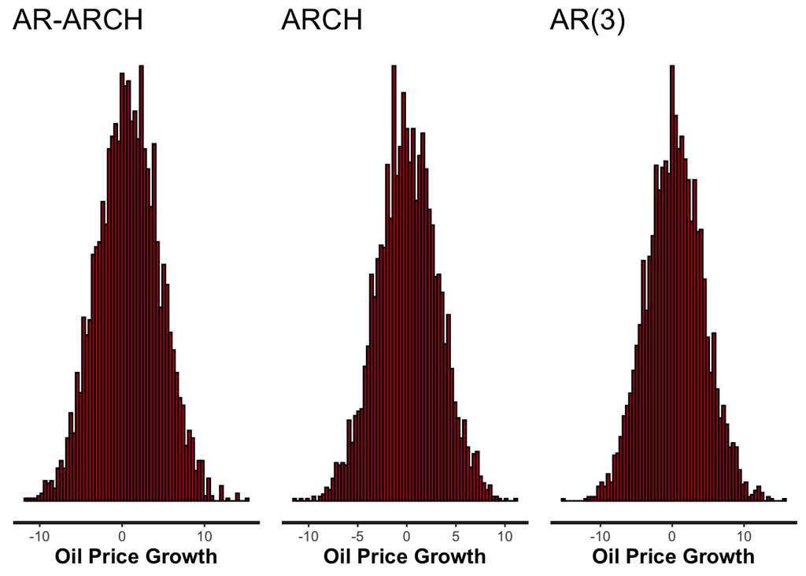

```r
grid.arrange(grobs=postpredplot,nrow=1,ncol=3)
```

## Dynamic Model Combination

- If producing a *sequence* of forecasts, $\{\widehat{y}_{t+1}\}_{t=1}^{T}$, and in posession of a sequence of forecast rules or models $\mathcal{F}_t$,
  - Can combine using a *different* $s_t\in\mathcal{S}$ every period $t$ to produce a **dynamic model combination**
- Simplest approach to this is just to run one of previous approaches given data available up to a fixed time
  - Use model selection, averaging or combination based on empirical risk, CV risk, or penalized risk
  - Use Bayesian model averaging, but update prior $\nu(m)$ using Bayes rule given incoming data
- Above approaches are sensible given stationarity and enough initial data to ensure good approximation of risk
  - At start, with no or little data, performance not guaranteed, so need good starting values
  - In Bayesian approach, can use prior information to set initial guesses
  - In statistical approach, start with reasonable starting value, like equal weights, and use heavy penalization to regularize
- Weights can be made to depend on context by fitting an explicitly time dependent model $\widehat{s}_t(\mathcal{Y}_t)$
  - Called **regime switching** models when performing selection each period
  - E.g., use one prediction rule in recession or crisis periods, and another in normal times

## Online Approaches

- If goal is regret rather than max or average risk, or data nonstationary, online approaches become attractive
- Follow the Regularized Leader is **exactly** penalized ERM each period
  - **Hedge** performs model selection each period, and **exponential weights** performs model averaging
    - Both with entropy penalty $\sum_{m=1}^{M}s_m\log s_m$
  - Online regression can be implemented by online (projected) gradient descent, corresponding to ridge penalty
- Methods can also be made equivalent to Bayesian procedures with appropriate choice of likelihood and priors
  - Maximum A Posteriori estimate is Penalized ERM with loss equal to log likelihood and penalty given by log prior
- Equivalence of online and statistical approaches suggests robust performance whether goal is regret or risk
  - Penalization useful to ensure stability against arbitrary sequences, which reduces both regret and excess risk

## Conclusions

- We have now seen a wide variety of forecast methods, each with pros and cons
- With many forecasts, can combine them to produce potentially better forecasts
  - Selection rules pick a single one
  - Averaging rules create weighted combinations
  - Regression approaches create combinations outside set of averages
- Larger sets of combinations can yield improvements on any individual forecast
- Can choose combination based on measures of performance
  - Empirical, penalized empirical, or cross validated Risk in statistical approach
  - Posterior updating over models for Bayes approach
  - Dynamic and online combinations
- Combinations of diverse methods can capture features not achievable with any one method

## References

- Francis Diebold (2017) *[Forecasting in Economics, Business, Finance and Beyond](https://www.sas.upenn.edu/~fdiebold/Teaching221/Forecasting.pdf)*, Part IV: Forecast Evaluation and Combination
  - Useful source on statistical approach to forecast combination